# S1.9. Code used to analyse summary statistics and count data of all data, and visualise systematic review results.

Clare Vernon

2025-03-11

## 1. Set working directory, loading data and packages

Load the data into R:

```r
library(readr)
df <- read_csv("S2.3 Dataset of results included in systematic review meta-analysis.csv")
```

```
## ──────────────────────────────────────────────────────── Delimiter: "," chr
## (106): QualQuantInc, Author, Study, StudyType, Journal, Study ID, Fire, ... dbl
## (72): UniqueCode, PubYear, Elev_Est_Lower, Elev_Est_Upper, coord.x.map,... lgl
## (3): T.C.FinalYr.Level, C.Change.Imputation / Notes, ...173
```

```r
head(df)
```

```
## # A tibble: 6 × 181
##   UniqueCode QualQuantInc Author      Study StudyType PubYear Journal `Study ID`
##        <dbl> <chr>        <chr>       <chr> <chr>       <dbl> <chr>   <chr>
## 1          1 QualOnly     Camac et a… Cama… Publishe…    2013 Austra… CH
## 2          2 Quant+Qual   Camac et a… Cama… Publishe…    2013 Austra… Ohb
## 3          3 Quant+Qual   Camac et a… Cama… Publishe…    2013 Austra… Oha
## 4          4 QualOnly     McDougall … McDo… Publishe…    2013 Ecolog… AlpineRd
## 5          5 Quant+Qual   McDougall … McDo… Publishe…    2013 Ecolog… AlpineRd
## 6          6 Quant+Qual   McDougall … McDo… Publishe…    2013 Ecolog… AlpineRd
## # ℹ 173 more variables: Fire <chr>, fire.sa <chr>, Grazing <chr>,
## #   grazing.sa <chr>, Tourism <chr>, tourism.sa <chr>, Elevation_Stated <chr>,
## #   Elevation_Est <chr>, Elev_Est_Lower <dbl>, elev.lower.sa <chr>,
## #   Elev_Est_Upper <dbl>, elev.upper.sa <chr>, Slope <chr>, Landform <chr>,
## #   Snow <chr>, `Bare ground` <chr>, bareground.sa <chr>, Studysite <chr>,
## #   site.map <chr>, coord.x.map <dbl>, coord.y.map <dbl>, studysite.sa <chr>,
## #   Studysite.aggregate <chr>, StudySite.LatLong <chr>, …
```

### 1.1. Install packages, and load packages into library.

May need to install the following packages: install.packages(“rnaturalearth”) install.packages(“rnaturalearthdata”) install.packages(“ggspatial”) install.packages(“giscoR”) install.packages(“maps”) install.packages(“ggrepel”) install.packages(“maps”) install.packages(“ggrepel”) install.packages(“writexl”) install.packages(“MuMIn”) install.packages(“car”) install.packages(“doBy”) install.packages(“reshape2”) install.packages(esc) install.packages(“GGally”) install.packages(“ggtext”) install.packages(“ozmaps”)

Package for drawing NSW / Victorian borders: install.packages(“devtools”) devtools::install_github(“thomasp85/patchwork”) install.packages(“meta”) install.packages(“dmetar”) install.packages(“esc”)

Needed for Orchard, see https://daniel1noble.github.io/orchaRd/introduction rm(list = ls()) devtools::install_github(“daniel1noble/orchaRd”, ref = “main”, force = TRUE) pacman::p_load(devtools, tidyverse, metafor, patchwork, R.rsp, orchaRd, emmeans, ape, phytools, flextable)

Once installed, load packages into library.

```r
library("ggplot2")
library("sf")
library("rnaturalearth")
library("rnaturalearthdata")
library("ggspatial")
library("giscoR")
library("dplyr")
library("maps")
library("ggrepel")
library("tidyr")
library("reshape2")
library("dplyr")
library("stringr")
library(see)
library(MuMIn)
library(car)
library(doBy)
library(forcats)
library(writexl)
library(ggtext)
library(patchwork)
library("cowplot")
library(orchaRd)
library(emmeans)
library(flextable)
library(devtools)
library(meta)
library(dmetar)
library(esc)
library(clubSandwich)
# Load data
library(readr)
df <- read_csv("S2.3 Dataset of results included in systematic review meta-analysis.csv")
# Create unique identifier for later on
df$AuthorStudyID <-  paste(df$`CADIMA Ref`, df$Author, df$`Study ID`, sep = "_")
# Remove any NA
df$Record.type <- df$StudyType
df$Record.type <- str_replace(df$Record.type, "Unpublished", "Private dataset")
```

## 2. Characterising studies included in the review, meta-analysis and linear models.

### 2.1. Figure 2. Map of studies.

```r
# Setting up- download the mapping data from online.
theme_set(theme_bw()) # for ggplot2
world <- ne_countries(scale = "medium", returnclass = "sf")
class(world)
```

```
## [1] "sf"         "data.frame"
```

```r
worldmap <- ne_countries(scale = 'medium', type = 'map_units',
                    returnclass = 'sf')
head(worldmap[c('name', 'continent')])
```

```
## Simple feature collection with 6 features and 2 fields
## Geometry type: MULTIPOLYGON
## Dimension:     XY
## Bounding box:  xmin: -73.36621 ymin: -22.40205 xmax: 109.4449 ymax: 41.9062
## Geodetic CRS:  WGS 84
##        name     continent                       geometry
## 1  Zimbabwe        Africa MULTIPOLYGON (((31.28789 -2...
## 2    Zambia        Africa MULTIPOLYGON (((30.39609 -1...
## 3     Yemen          Asia MULTIPOLYGON (((53.08564 16...
## 4   Vietnam          Asia MULTIPOLYGON (((104.064 10....
## 5 Venezuela South America MULTIPOLYGON (((-60.82119 9...
## 6   Vatican        Europe MULTIPOLYGON (((12.43916 41...
```

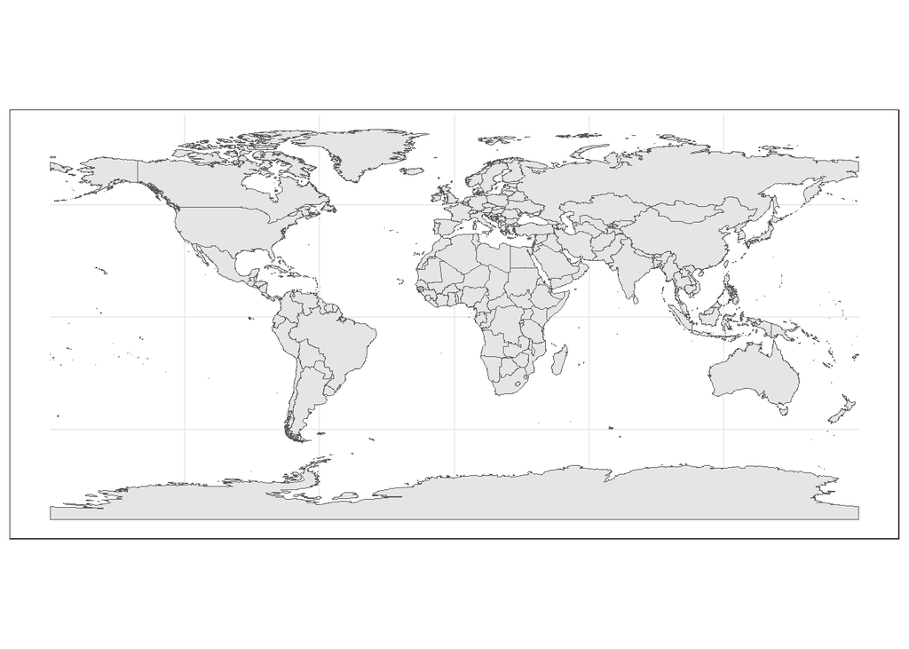

```r
ggplot() + geom_sf(data=worldmap) + theme_bw() # World map
```

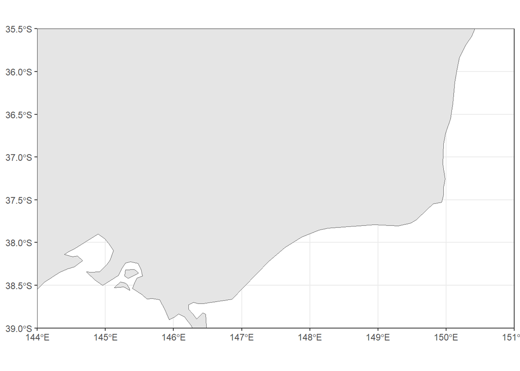

```r
aus <- worldmap[worldmap$name == 'Australia',]


# NSW / Vic extents
ggplot() + geom_sf(data = worldmap) + # This is the map with results
  coord_sf(xlim = c(144, 151), ylim = c(-35.5, -39), expand = FALSE) # Basic map,  now to overlay count data
```

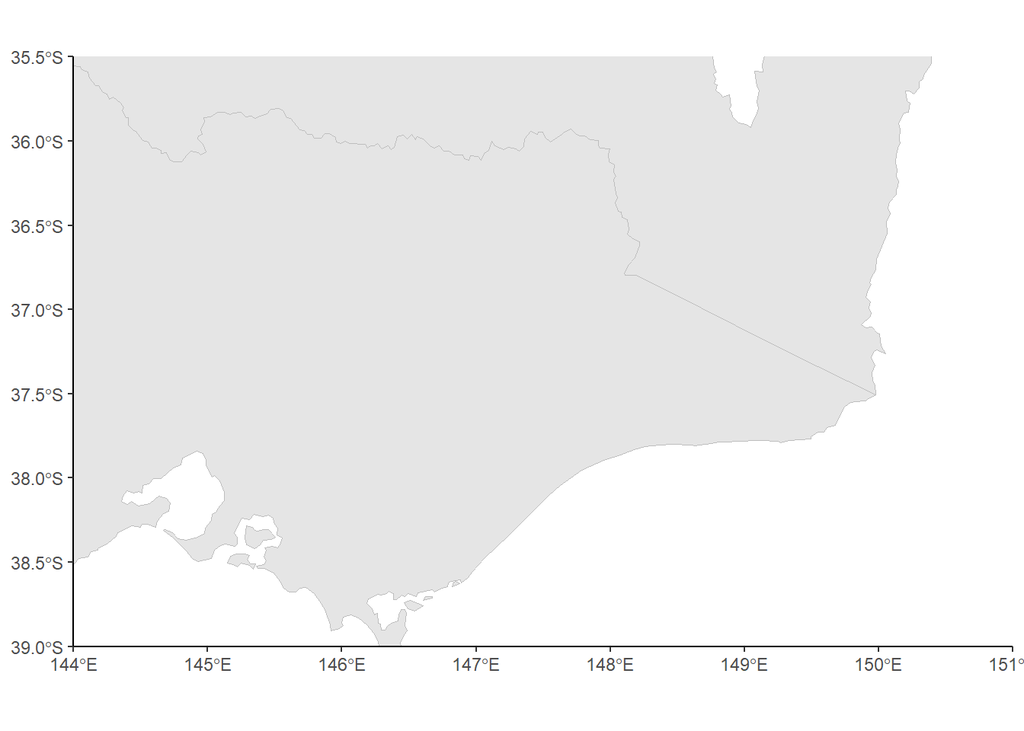

```r
# Add the NSW / Victorian border using ozmap
aus_states <- ozmaps::ozmap_states
nsw_vic_border <- aus_states[aus_states$NAME %in% c("New South Wales", "Victoria", "Tasmania"), ]
map_mainland <- ggplot() +
  geom_sf(data = aus_states, fill = "white", color = "grey") +  # Map outline
  geom_sf(data = nsw_vic_border, color = "grey", size = 1.2) +  # Border overlay
  coord_sf(xlim = c(144, 151), ylim = c(-35.5, -39), expand = FALSE) +  # Zoomed region
  theme_classic()
map_mainland
```

```r
# Organising the data
df_mapcount <- df %>%
  group_by(site.map) %>% # group by each suty site region
  summarise(Count = n_distinct(AuthorStudyID), Lat = unique(coord.x.map), Long = unique(coord.y.map)) # How many studies per location?
df_mapcount
```

```
## # A tibble: 14 × 4
##    site.map                      Count   Lat  Long
##    <chr>                         <int> <dbl> <dbl>
##  1 Bogong High Plains               37 -36.9  147.
##  2 Central East Plateau             10 -41.8  147.
##  3 Gungartan                         1 -36.3  148.
##  4 Guthega                           9 -36.4  148.
##  5 Hartz Mountains National Park     1 -43.2  147.
##  6 Holmes Plains                     2 -37.4  147.
##  7 Kiandra                           1 -35.9  148.
##  8 Liawenee                          1 -41.9  147.
##  9 Middlesex Plains                  1 -41.5  146.
## 10 Mt Bogong                         2 -36.7  147.
## 11 Mt Kosciuszko region             19 -36.5  148.
## 12 Mt Wellington                     2 -42.9  147.
## 13 Summits across Tasmania           1 -42.1  147.
## 14 Wellington Plains                 3 -37.5  147.
```

```r
unique(df_mapcount$site.map)
```

```
##  [1] "Bogong High Plains"            "Central East Plateau"
##  [3] "Gungartan"                     "Guthega"
##  [5] "Hartz Mountains National Park" "Holmes Plains"
##  [7] "Kiandra"                       "Liawenee"
##  [9] "Middlesex Plains"              "Mt Bogong"
## [11] "Mt Kosciuszko region"          "Mt Wellington"
## [13] "Summits across Tasmania"       "Wellington Plains"
```

```r
# mainland region
mainland_plotted <- map_mainland +
  coord_sf(xlim = c(142, 152), ylim = c(-35, -44), expand = FALSE) + annotation_north_arrow(location = "br", which_north = "true")
```

```
## replace the existing one.
```

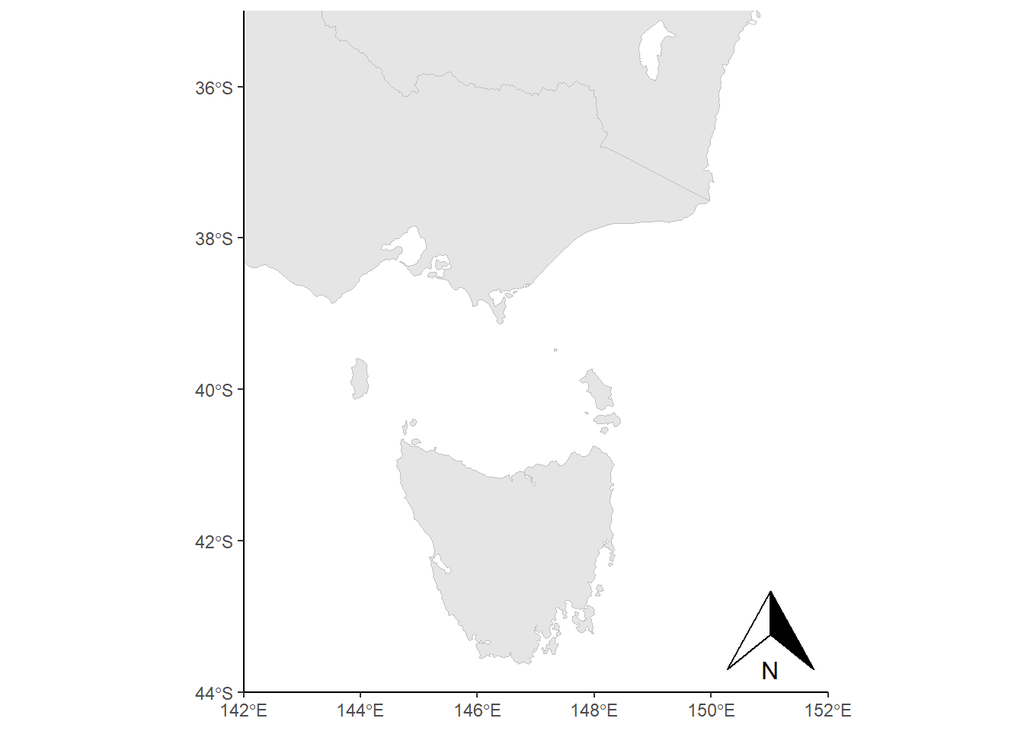

```r
mainland_plotted
```

```r
# draw a blank mainland for inset in the NSW and Victorian maps

# box for nsw
nsw_box <- data.frame(
  xmin = 148, xmax = 149,
  ymin = -35.8, ymax = -36.58
)
# box for vic
vic_box <- data.frame(
  xmin = 146.5, xmax = 148.5,
  ymin = -36.5, ymax = -37.8
)
# box for tas1
tas1_box <- data.frame(
  xmin = 145.8, xmax = 147.1,
  ymin = -41.4, ymax = -42
)
# box for tas2
tas2_box <- data.frame(
  xmin = 146.6, xmax = 147.6,
  ymin = -42.8, ymax = -43.4
)

# Add to the map
region_map <- mainland_plotted +
  geom_rect(data = nsw_box,
            aes(xmin = xmin, xmax = xmax, ymin = ymin, ymax = ymax),
            fill = NA, color = "#009E73", size = 1.2) +  # NSW
  geom_rect(data = vic_box,
            aes(xmin = xmin, xmax = xmax, ymin = ymin, ymax = ymax),
            fill = NA, color = "#D55E00", size = 1.2) + # VIC
  geom_rect(data = tas1_box,
            aes(xmin = xmin, xmax = xmax, ymin = ymin, ymax = ymax),
            fill = NA, color =  "#E69F00", size = 1.2)  + # Tas1
  geom_rect(data = tas2_box,
            aes(xmin = xmin, xmax = xmax, ymin = ymin, ymax = ymax),
            fill = NA, color =  "#0072B2", size = 1.2) + fixed_plot_aspect(ratio = 1) + annotation_scale()  # Tas2 +
region_map <- region_map +  annotate("text", x = 147, y = -35.5, label = "New South Wales", size = 4, fontface = "bold", colour = "#009E73") +
  annotate("text", x = 146.5, y = -36.2, label = "Victoria", size = 4, fontface = "bold", colour = "#D55E00") +
  annotate("text", x = 145, y = -41, label = "Northern Tasmania", size = 4, fontface = "bold", colour = "#E69F00") +
  annotate("text", x = 146, y = -42.5, label = "Sothern Tasmania", size = 4, fontface = "bold", colour = "#0072B2") +
  fixed_plot_aspect(ratio = 1) +
  xlab("Longitude") + ylab("Latitude")

# Now make 3 maps to show the regions, and then have the 'zoomed out' (mainland) map inset
# NSW first
mainland_nsw <- map_mainland +
  coord_sf(xlim = c(146, 149), ylim = c(-35.5, -36.58), expand = FALSE)
```

```
## replace the existing one.
```

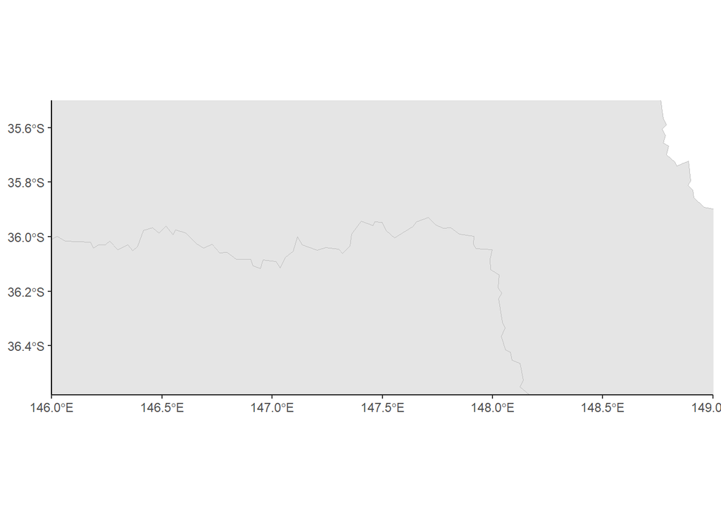

```r
mainland_nsw
```

```r
map_nsw  <- mainland_nsw +
  geom_point(data = df_mapcount, aes(x = Long, y = Lat, size = Count)) +
  geom_text(data = df_mapcount, aes(x = Long, y = Lat, label = site.map),
            size = 4, check_overlap = TRUE, hjust = -0.1, vjust = -0.6) +
  scale_size_continuous(range = c(1, 10)) + theme(legend.position="none") +
  coord_sf(xlim = c(148, 149), ylim = c(-35.8, -36.58), expand = FALSE) + annotation_scale() +
  theme(panel.border = element_rect(colour = "#009E73", fill=NA, linewidth=2)) +
  ggtitle("New South Wales") + xlab("Longitude") + ylab("Latitude")
```

```
## replace the existing one.
```

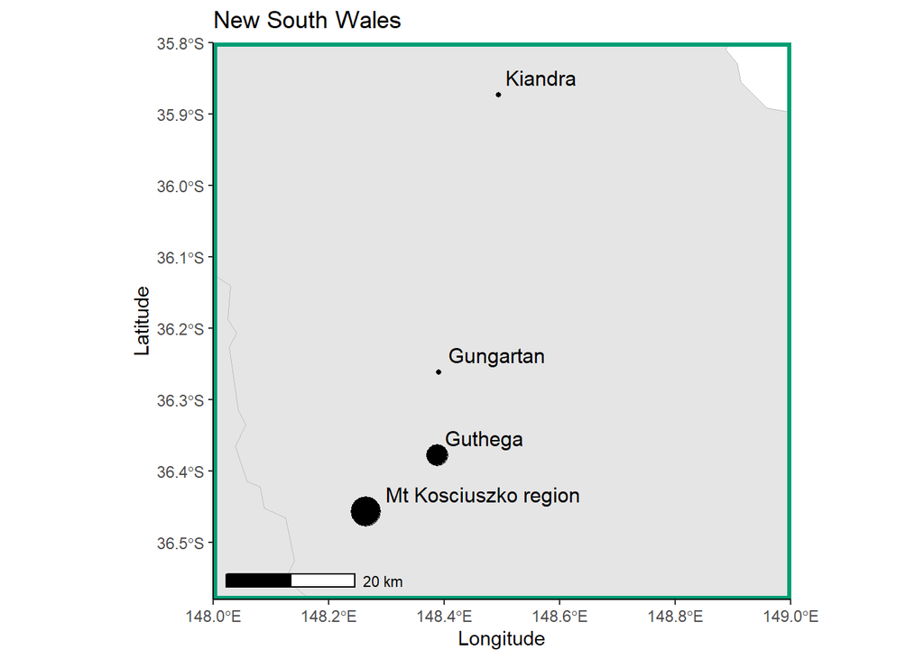

```r
map_nsw <- map_nsw + fixed_plot_aspect(ratio = 1)
map_nsw
```

```r
# Vic next
map_vic <- map_mainland +
  geom_point(data = df_mapcount, aes(x = Long, y = Lat, size = Count)) +
  geom_text(data = df_mapcount, aes(x = Long, y = Lat, label = site.map),
            size = 4, check_overlap = TRUE, hjust = -0.15, vjust = -0.4)  +
  scale_size_continuous(range = c(1, 10)) + theme(legend.position="none") +
  coord_sf(xlim = c(146.5, 148.5), ylim = c(-36.5, -37.8), expand = FALSE) + annotation_scale() +
  theme(panel.border = element_rect(colour =  "#D55E00", fill=NA, linewidth=2)) +
  ggtitle("Victoria")   + xlab("Longitude") + ylab("Latitude")
```

```
## replace the existing one.
```

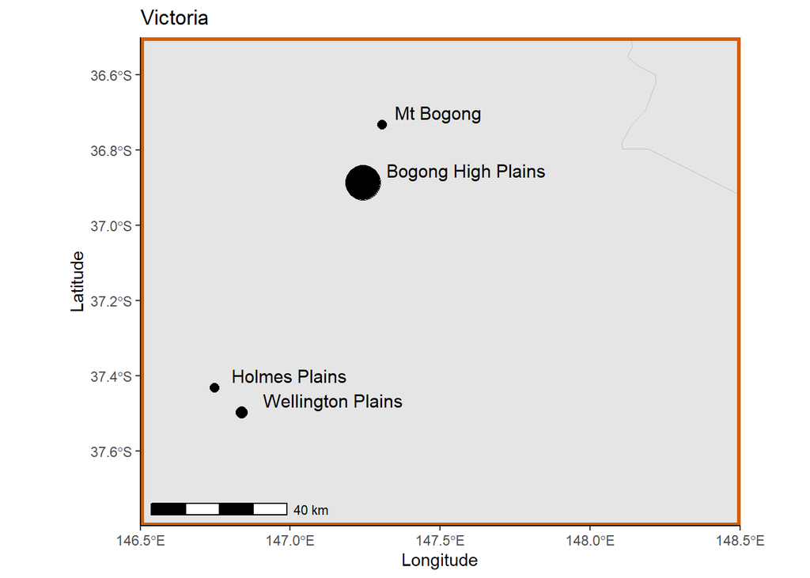

```r
map_vic <- map_vic + fixed_plot_aspect(ratio = 1)
map_vic
```

```r
# Tas last
map_tas1 <- map_mainland +
  geom_point(data = df_mapcount, aes(x = Long, y = Lat, size = Count)) +
  geom_text(data = df_mapcount, aes(x = Long, y = Lat, label = site.map),
            size = 4, check_overlap = TRUE, hjust = -0.2) +
  scale_size_continuous(range = c(1, 10)) + theme(legend.position="none") +
  coord_sf(xlim = c(145.8, 147.1), ylim = c(-41.4, -42), expand = FALSE) + annotation_scale() +
  theme(panel.border = element_rect(colour =  "#E69F00", fill=NA, linewidth=2)) +
  ggtitle ("Northen Tasmania") + xlab("Longitude") + ylab("Latitude")
```

```
## replace the existing one.
```

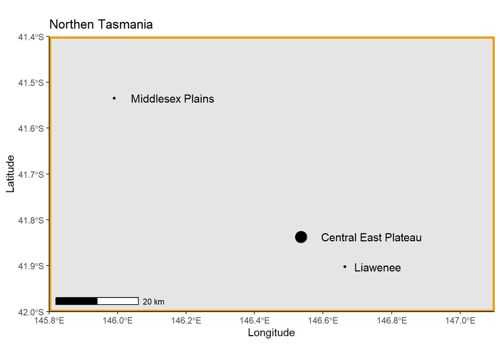

```r
map_tas1 <- map_tas1 + fixed_plot_aspect(ratio = 1)
map_tas1
```

```r
map_tas2 <- map_mainland +
  geom_point(data = df_mapcount, aes(x = Long, y = Lat, size = Count)) +
  geom_text(data = df_mapcount, aes(x = Long, y = Lat, label = site.map),
            size = 4, check_overlap = TRUE, hjust = -0.2) +
  scale_size_continuous(range = c(1, 10)) +
  coord_sf(xlim = c(146.6, 147.6), ylim = c(-42.8, -43.4), expand = FALSE) + annotation_scale() +
  theme(panel.border = element_rect(colour =  "#0072B2", fill=NA, linewidth=2)) +
  ggtitle("Southern Tasmania") + xlab("Longitude") + ylab("Latitude")
```

```
## replace the existing one.
```

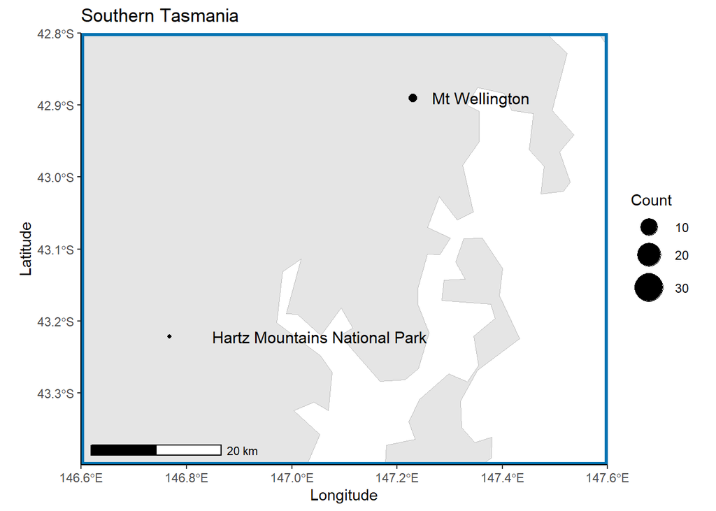

```r
map_tas2 <- map_tas2 + fixed_plot_aspect(ratio = 1)
map_tas2
```

```
## Scale on map varies by more than 10%, scale bar may be inaccurate
```

[figure not shown]

```r
p1 <- ((map_nsw / map_vic)) + plot_layout(guides = 'collect', axes = "collect")
p2 <- ((map_tas1 / map_tas2)) + plot_layout(guides = 'collect', axes = "collect")
final_figure <- p1 | region_map | p2
final_figure
```

### 2.2. Figure 3. Count of number of reports, for each year of publication.

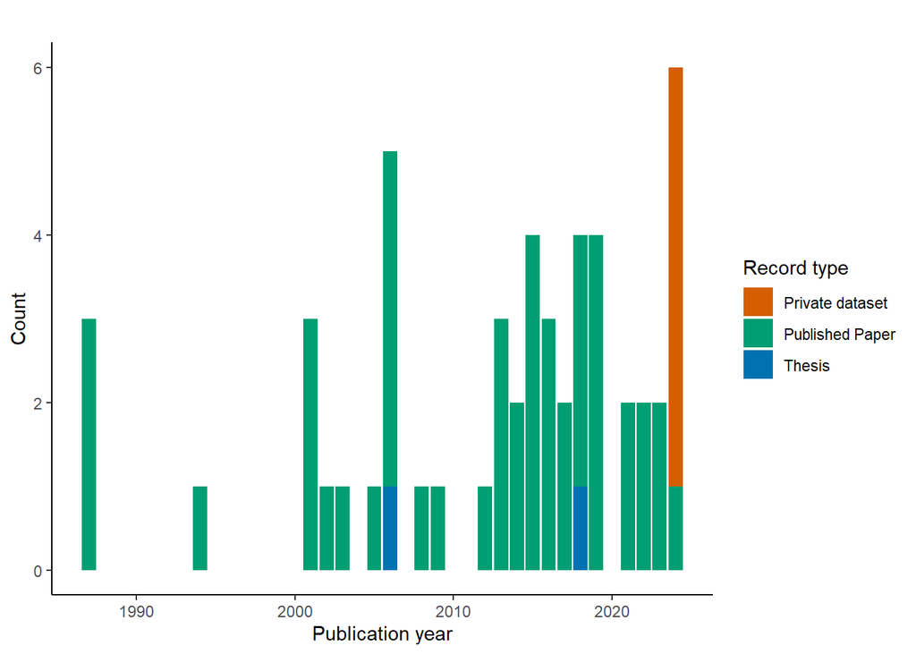

```r
p1 <- df %>%
  group_by(PubYear, Record.type, Treatment_Thematic) %>%
  summarise(Count = n_distinct(Study)) %>%
  ggplot(aes(x = PubYear, y = Count, fill = Record.type)) +
  geom_bar(position = "stack", stat="identity") +
  scale_fill_manual(values =  c("#D55E00", "#009E73", "#0072B2" )) +
  theme_classic() +
  ylab("Count") +
  xlab("Publication year") +
  guides(fill=guide_legend(title="Record type")) +
  ggtitle("All driving processes")
p1 + ggtitle("")
```

```r
# Does the impact of a driving process (promote, reduce, no effect) significantly differ between ecosystem types?
test <- chisq.test(table(df$Aggregate.InitialES, df$QualDirection))
test
```

```
##
##  Pearson's Chi-squared test
##
## data:  table(df$Aggregate.InitialES, df$QualDirection)
## X-squared = 42.534, df = 16, p-value = 0.0003283
```

## 3. Systematic review

### 3.1. Count of results, for each species type.

The table produced is presented in **Supplementary Material S3. Extended results.**

```r
df_x <- df %>%
  filter(Response.Level == "Species") %>%
  group_by(Treatment_Thematic, Response, Metric.Aggregate, QualDirection, Family, Alpine.Zone, `Groundwater Association`, Seeder.Resprouter) %>%
  summarise(Reports = n_distinct(UniqueCode), Studies = n_distinct(Study), )
```

```
## 'Metric.Aggregate', 'QualDirection', 'Family', 'Alpine.Zone', 'Groundwater
## Association'. You can override using the `.groups` argument.
```

```r
df_x
```

```
## # A tibble: 217 × 10
## # Groups:   Treatment_Thematic, Response, Metric.Aggregate, QualDirection,
## #   Family, Alpine.Zone, Groundwater Association [217]
##    Treatment_Thematic Response Metric.Aggregate QualDirection Family Alpine.Zone
##    <chr>              <chr>    <chr>            <chr>         <chr>  <chr>
##  1 Climate change     Acrotha… Cover-abundance  Promote       Erica… Alpine
##  2 Climate change     Acrotha… Cover-abundance  Reduce        Erica… Alpine
##  3 Climate change     Acrotha… Cover-abundance  Reduce        Erica… Alpine Sub…
##  4 Climate change     Asterol… Cover-abundance  No change     Rutac… Alpine Sub…
##  5 Climate change     Asterol… Cover-abundance  Promote       Rutac… Alpine Sub…
##  6 Climate change     Asterol… Height           Promote       Rutac… Alpine Sub…
##  7 Climate change     Baeckea… Cover-abundance  Promote       Myrta… Subalpine
##  8 Climate change     Baeckea… Cover-abundance  Reduce        Myrta… Subalpine
##  9 Climate change     Bellend… Cover-abundance  Promote       Prote… Alpine Sub…
## 10 Climate change     Coprosm… Cover-abundance  Promote       Rubia… Non-alpine
## # ℹ 207 more rows
## # ℹ 4 more variables: `Groundwater Association` <chr>, Seeder.Resprouter <chr>,
## #   Reports <int>, Studies <int>
```

### 3.2. Figure 4. Count of studies reporting a promoting, reducing and no effect for all driving processes, and for driving processes grouped under climate change.

```r
# Graph a. All driving processes.
df_y <- df %>%
  group_by(Treatment_Thematic, Response.Level, QualDirection) %>%
  summarise(Count = n_distinct(UniqueCode)) # Filter by metric
```

```
## can override using the `.groups` argument.
```

```r
colours <- c("#0072B2", "#009E73", "#D55E00", "#56B4E9" ) # ID colours
df_y_neg <- df_y %>%
  mutate(
    Count = case_when(
      QualDirection == "Reduce"  ~ -Count,
      TRUE ~ Count
    ),)
unique(df_y_neg$Treatment_Thematic)
```

```
## [1] "Climate change"
## [2] "Climate change  + Grazing"
## [3] "Fire"
## [4] "Fire + Climate change"
## [5] "Fire + Exotic species planted, fertiliser applied"
## [6] "Fire + Grazing"
## [7] "Grazing"
## [8] "Soil / substrate"
## [9] "Tourism"
```

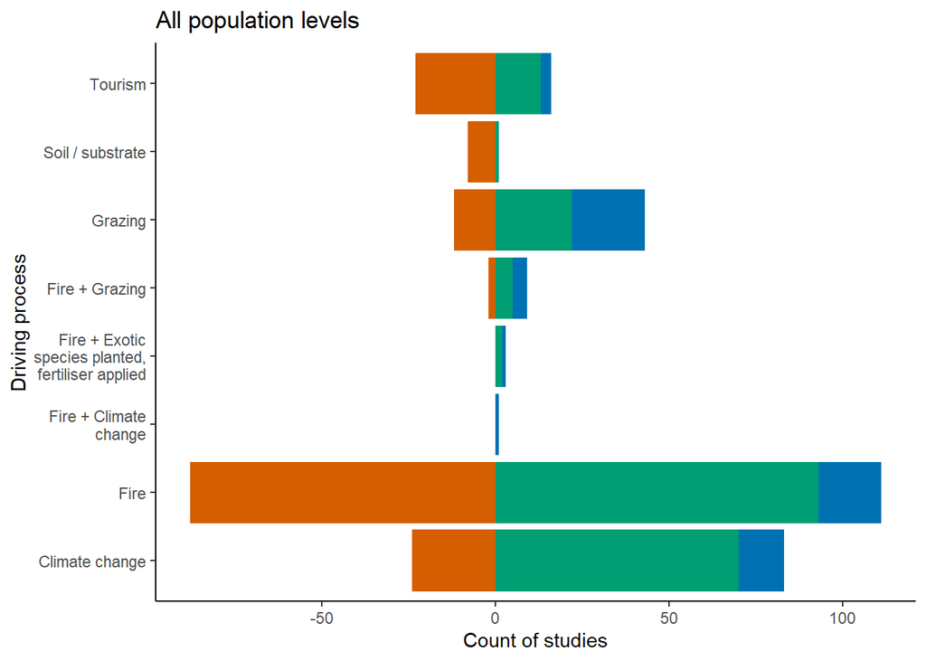

```r
df_y_neg$Treatment_Thematic <- factor(df_y_neg$Treatment_Thematic,
                                      levels = c("Tourism",
                                                 "Soil / substrate",
                                                 "Grazing",
                                                 "Fire + Grazing",
                                                 "Fire + Exotic species planted, fertiliser applied",
                                                 "Fire + Climate change",
                                                 "Fire",
                                                 "Climate change + Grazing",
                                                 "Climate change"))
df_y_neg$Treatment_Thematic <- str_wrap(df_y_neg$Treatment_Thematic, width = 20)
df_y_neg2 <- df_y_neg %>%
  filter(!is.na(Treatment_Thematic))

p_all <- df_y_neg2 %>%
  ggplot(aes(x = Treatment_Thematic, y = Count, fill = QualDirection)) +
  geom_bar(position = "stack", stat = "identity") +
  scale_fill_manual(values = colours) +
  theme_classic() +
  coord_flip() +
  guides(fill=guide_legend(title="Shrub response")) +
  ggtitle("All population levels") +
  ylab("Count of studies") + xlab("Driving process") +
    scale_x_discrete(labels = function(x) str_wrap(x, width = 20)) +
  theme(legend.position="none")
p_all
```

```r
# Graph b. Climate change-related driving processes only.
df_y <- df %>%
  filter(Treatment_Thematic ==  "Climate change" ) %>%
  group_by(TreatmentAggregate2, Response.Level, QualDirection) %>%
  summarise(Count = n_distinct(UniqueCode))
```

```
## You can override using the `.groups` argument.
```

```r
colours <- c("#0072B2", "#009E73", "#D55E00", "#56B4E9" )
head(df_y)
```

```
## # A tibble: 6 × 4
## # Groups:   TreatmentAggregate2, Response.Level [5]
##   TreatmentAggregate2                         Response.Level QualDirection Count
##   <chr>                                       <chr>          <chr>         <int>
## 1 Drought (historical)                        Shrub          Promote           1
## 2 Drought (ongoing)                           Shrub          Promote           3
## 3 Drought (ongoing)                           Species        No change         2
## 4 Rainfall (decrease) + Temperature (increas… Shrub          Promote           1
## 5 Rainfall (decrease) + Temperature (increas… Species        Promote           3
## 6 Rainfall (decrease) + Temperature (increas… Species        Reduce            3
```

```r
df_y_neg <- df_y %>%
  mutate(
    Count = case_when(
      QualDirection == "Reduce"  ~ -Count,
      TRUE ~ Count
    ),)
unique(df_y_neg$TreatmentAggregate2)
```

```
## [1] "Drought (historical)"
## [2] "Drought (ongoing)"
## [3] "Rainfall (decrease) + Temperature (increase)"
## [4] "Rainfall (increase)"
## [5] "Snow depth (decrease) + Temperature (increase)"
## [6] "Snowmelt (earlier)"
## [7] "Temperature (increase)"
## [8] "Wind speed + Adiabatic lapse rate"
```

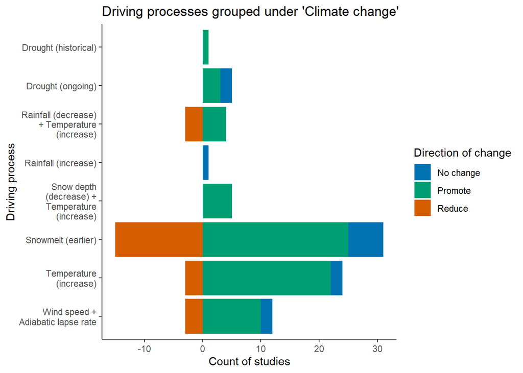

```r
df_y_neg$TreatmentAggregate2 <- factor(df_y_neg$TreatmentAggregate2,
                                      levels = c("Wind speed + Adiabatic lapse rate"  ,
                                                 "Temperature (increase)" ,
                                                 "Snowmelt (earlier)"  ,
                                                 "Snow depth (decrease) + Temperature (increase)",
                                                 "Rainfall (increase)",
                                                 "Rainfall (decrease) + Temperature (increase)",
                                                 "Drought (ongoing)",
                                                 "Drought (historical)"))
df_y_neg$Treatment2 <- str_wrap(df_y_neg$TreatmentAggregate2, width = 20)
p_cc <- df_y_neg %>%
  ggplot(aes(x = TreatmentAggregate2, y = Count, fill = QualDirection)) +
  geom_bar(position = "stack", stat = "identity") +
  scale_fill_manual(values = colours) +
  theme_classic() +
  coord_flip() +
  guides(fill=guide_legend(title="Direction of change")) +
  ggtitle("Driving processes grouped under 'Climate change'") +
  scale_x_discrete(labels = function(x) str_wrap(x, width = 20)) +
  ylab("Count of studies") + xlab("Driving process")
p_cc
```

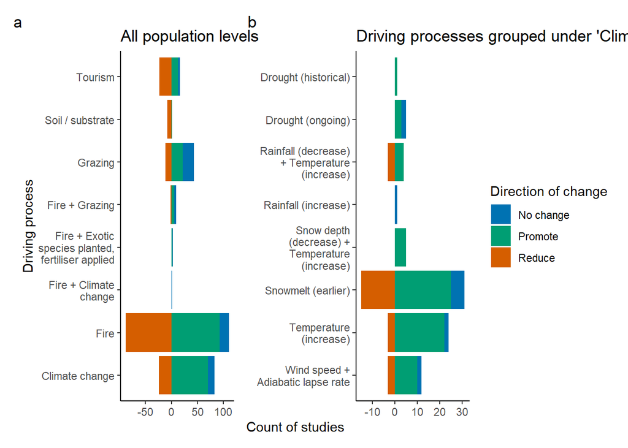

```r
# Combining both into Figure 4.
p_allpop <- p_all | p_cc
p_final <- p_allpop + plot_layout(guides = 'collect', axes = "collect", widths = c(1,1)) + plot_annotation(tag_levels = 'a')
p_final
```

```r
test <- chisq.test(table(df$Treatment_Thematic, df$QualDirection))
test
```

```
##
##  Pearson's Chi-squared test
##
## data:  table(df$Treatment_Thematic, df$QualDirection)
## X-squared = 77.952, df = 16, p-value = 3.884e-10
```

```r
test <- chisq.test(table(df$Response.Level, df$QualDirection))
test
```

```
##
##  Pearson's Chi-squared test
##
## data:  table(df$Response.Level, df$QualDirection)
## X-squared = 22.949, df = 4, p-value = 0.0001296
```

**Outcome of chi-squared tests:** significant differences between driving processes and direction of change, and between population scales and direction of change.

### 3.3. Figure 5. Count of studies reporting a promoting, reducing and no effect of a driving process when assessed at different population scales, and using different metrics of change.

```r
# Graph a. Population scales
df_y <- df %>%
  group_by(Treatment_Thematic, Metric.Aggregate, QualDirection) %>%
  summarise(Count = n_distinct(UniqueCode)) # Filter by metric
```

```
## You can override using the `.groups` argument.
```

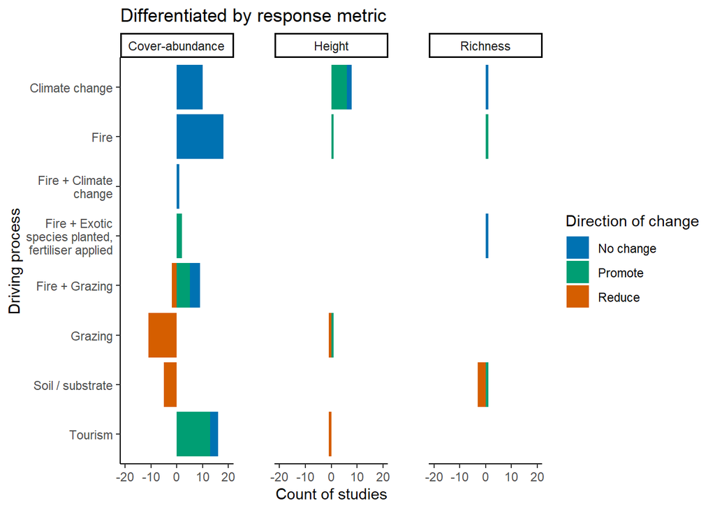

```r
colours <- c("#0072B2", "#009E73", "#D55E00", "#56B4E9" ) # ID colours
# Make the "Reduce" a negative value
df_y$Treatment_Thematic <- factor(df_y$Treatment_Thematic,
                                      levels = c("Tourism",
                                                 "Soil / substrate",
                                                 "Grazing",
                                                 "Fire + Grazing",
                                                 "Fire + Exotic species planted, fertiliser applied",
                                                 "Fire + Climate change",
                                                 "Fire",
                                                 "Climate change + Grazing",
                                                 "Climate change"))
df_y_neg <- df_y %>%
  mutate(
    Count = case_when(
      QualDirection == "Reduce"  ~ -Count,
      TRUE ~ Count
    ),)
df_y_neg2 <- df_y_neg %>%
  filter(!is.na(Treatment_Thematic))
df_y_neg$Treatment2 <- str_wrap(df_y_neg$Treatment_Thematic, width = 20)
p_metric <- df_y_neg2 %>%
  ggplot(aes(x = Treatment_Thematic, y = Count, fill = QualDirection)) +
  geom_bar(position = "stack", stat = "identity") +
  scale_fill_manual(values = colours) +
  theme_classic() +
  coord_flip() +  # Flip axes
  facet_wrap(vars(Metric.Aggregate)) +  # Flexible scaling for facets
  theme(        panel.spacing = unit(2, "lines")) + guides(fill=guide_legend(title="Direction of change")) + ylab("Count of studies") + xlab("Driving process") + ylim (-20, 20) +
  ggtitle("Differentiated by response metric") +
  scale_x_discrete(labels = function(x) str_wrap(x, width = 20))
p_metric
```

```r
# Graph b. Metrics of change
df_y <- df %>%
  group_by(Treatment_Thematic, Response.Level, QualDirection) %>%
  summarise(Count = n_distinct(UniqueCode)) # Filter by metric
```

```
## can override using the `.groups` argument.
```

```r
colours <- c("#0072B2", "#009E73", "#D55E00", "#56B4E9" ) # ID colours
df_y <- df_y %>%
  filter(!is.na(Treatment_Thematic))
unique(df_y$Treatment_Thematic)
```

```
## [1] "Climate change"
## [2] "Climate change  + Grazing"
## [3] "Fire"
## [4] "Fire + Climate change"
## [5] "Fire + Exotic species planted, fertiliser applied"
## [6] "Fire + Grazing"
## [7] "Grazing"
## [8] "Soil / substrate"
## [9] "Tourism"
```

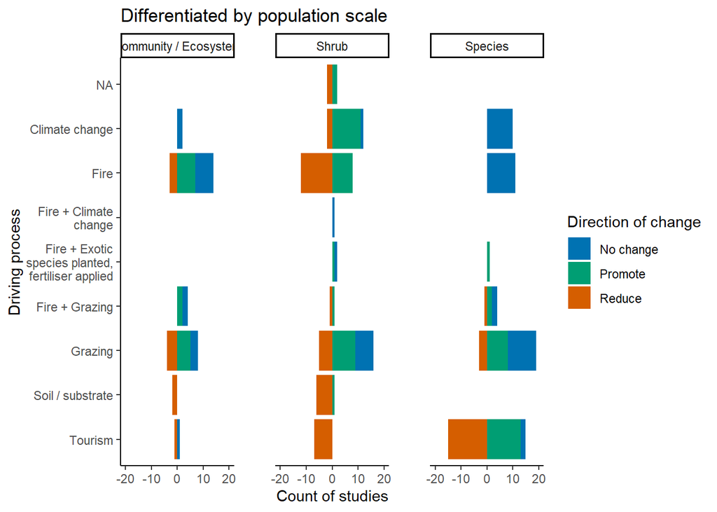

```r
df_y$Treatment_Thematic <- factor(df_y$Treatment_Thematic,
                                      levels = c("Tourism",
                                                 "Soil / substrate",
                                                 "Grazing",
                                                 "Fire + Grazing",
                                                 "Fire + Exotic species planted, fertiliser applied",
                                                 "Fire + Climate change",
                                                 "Fire",
                                                 "Climate change + Grazing",
                                                 "Climate change"))
# Make the "Reduce" a negative value
df_y_neg <- df_y %>%
  mutate(
    Count = case_when(
      QualDirection == "Reduce"  ~ -Count,
      TRUE ~ Count
    ),)
df_y_neg$Treatment2 <- str_wrap(df_y_neg$Treatment_Thematic, width = 20)
p_poplevel <- df_y_neg %>%
  ggplot(aes(x = Treatment_Thematic, y = Count, fill = QualDirection)) +
  geom_bar(position = "stack", stat = "identity") +
  scale_fill_manual(values = colours) +
  theme_classic() +
  coord_flip() +  # Flip axes
  facet_wrap(vars(Response.Level)) +  # Flexible scaling for facets
  theme(        panel.spacing = unit(2, "lines")) + guides(fill=guide_legend(title="Direction of change")) + ylab("Count of studies") + xlab("Driving process") + ylim (-20, 20) +
  ggtitle("Differentiated by population scale") +
  scale_x_discrete(labels = function(x) str_wrap(x, width = 20))
p_poplevel
```

```r
# Test of significant differences using chi-squared
test <- chisq.test(table(df$Response.Level, df$QualDirection))
test
```

```
##
##  Pearson's Chi-squared test
##
## data:  table(df$Response.Level, df$QualDirection)
## X-squared = 22.949, df = 4, p-value = 0.0001296
```

```r
test <- chisq.test(table(df$Response.Level, df$Treatment_Thematic))
test
```

```
##
##  Pearson's Chi-squared test
##
## data:  table(df$Response.Level, df$Treatment_Thematic)
## X-squared = 113.1, df = 16, p-value < 2.2e-16
```

```r
test <- chisq.test(table(df$Metric.Aggregate, df$QualDirection))
test
```

```
##
##  Pearson's Chi-squared test
##
## data:  table(df$Metric.Aggregate, df$QualDirection)
## X-squared = 3.916, df = 4, p-value = 0.4175
```

**Outcome of chi-squared tests:** No significant differences in reported outcome and the metric of change used. Significant differences between population scale and direction of change, population scale and driving process assessed.

### 3.4. Figure 6. Count of studies reporting a promoting, reducing and no effect of a driving process when assessed in different ecosystem types.

```r
df_y <- df %>%
  group_by(Treatment_Thematic, Aggregate.InitialES, QualDirection) %>%
  summarise(Count = n_distinct(UniqueCode)) # Filter by metric
```

```
## 'Aggregate.InitialES'. You can override using the `.groups` argument.
```

```r
colours <- c("#0072B2", "#009E73", "#D55E00" ) # ID colours
head(df_y)
```

```
## # A tibble: 6 × 4
## # Groups:   Treatment_Thematic, Aggregate.InitialES [2]
##   Treatment_Thematic Aggregate.InitialES         QualDirection Count
##   <chr>              <chr>                       <chr>         <int>
## 1 Climate change     Heathland (dry) / Grassland No change         5
## 2 Climate change     Heathland (dry) / Grassland Promote          35
## 3 Climate change     Heathland (dry) / Grassland Reduce            6
## 4 Climate change     Snowpatch                   No change         8
## 5 Climate change     Snowpatch                   Promote          35
## 6 Climate change     Snowpatch                   Reduce           18
```

```r
df_y <- df_y %>%
  filter(!is.na(Treatment_Thematic))
unique(df_y$Treatment_Thematic)
```

```
## [1] "Climate change"
## [2] "Climate change  + Grazing"
## [3] "Fire"
## [4] "Fire + Climate change"
## [5] "Fire + Exotic species planted, fertiliser applied"
## [6] "Fire + Grazing"
## [7] "Grazing"
## [8] "Soil / substrate"
## [9] "Tourism"
```

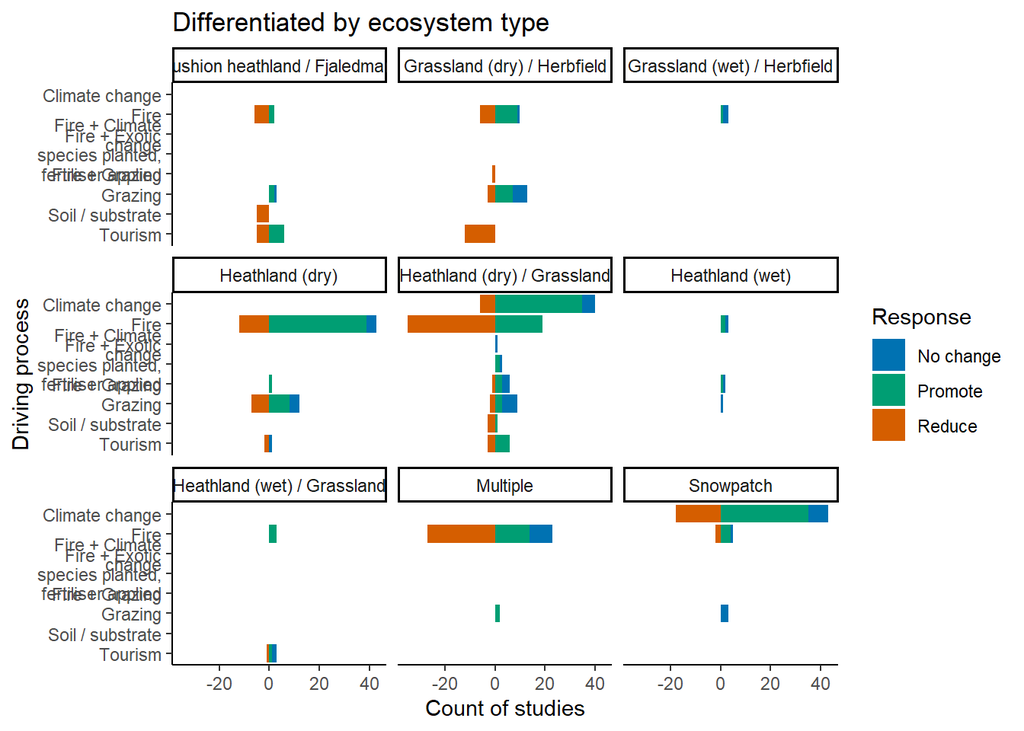

```r
df_y$Treatment_Thematic <- factor(df_y$Treatment_Thematic,
                                      levels = c("Tourism",
                                                 "Soil / substrate",
                                                 "Grazing",
                                                 "Fire + Grazing",
                                                 "Fire + Exotic species planted, fertiliser applied",
                                                 "Fire + Climate change",
                                                 "Fire",
                                                 "Climate change + Grazing",
                                                 "Climate change"))
# Make the "Reduce" a negative value
df_y_neg <- df_y %>%
  mutate(
    Count = case_when(
      QualDirection == "Reduce"  ~ -Count,
      TRUE ~ Count
    ),)
df_y_neg$Treatment2 <- str_wrap(df_y_neg$Treatment_Thematic, width = 20)
p_ES <-
  ggplot(data = subset(df_y_neg, !is.na(Treatment_Thematic)), aes(x = Treatment_Thematic, y = Count, fill = QualDirection)) +
  geom_bar(position = "stack", stat = "identity") + #, show.legend = FALSE) +
  scale_fill_manual(values = colours) +
  theme_classic() +
  coord_flip() +  # Flips the axes
  facet_wrap(vars(Aggregate.InitialES)) +
  guides(fill=guide_legend(title="Response")) +
  ggtitle("Differentiated by ecosystem type") +
  scale_x_discrete(labels = function(x) str_wrap(x, width = 20))
p_ES <- p_ES + ylab("Count of studies") + xlab("Driving process")
p_ES
```

```r
test <- chisq.test(table(df$Aggregate.InitialES, df$QualDirection))
test
```

```
##
##  Pearson's Chi-squared test
##
## data:  table(df$Aggregate.InitialES, df$QualDirection)
## X-squared = 42.534, df = 16, p-value = 0.0003283
```

**Outcome:** significant differences between ecosystem types, and the number of studies reporting a promoting, reducing or no effect on shrubs.